# Part I - Ford GoBike System Data Exploration

## Preliminary Wrangling

This data set includes information about individual rides made in a bike-sharing system covering the greater San Francisco Bay area by Ford Motors. The dataset to be explored today was obtained in the month of February in 2019.

```python
# import all packages to be used and set plots to be displayed inline
import numpy as np
import pandas as pd
import matplotlib.pyplot as plt
import seaborn as sb

%matplotlib inline
```

```python
# Read the csv file using pandas
rides_m = pd.read_csv('201902-fordgobike-tripdata.csv')

# Display data to see what it contains
rides_m.head(10)
```

|  | duration_sec | start_time | end_time | start_station_id | start_station_name | start_station_latitude | start_station_longitude | end_station_id | end_station_name | end_station_latitude | end_station_longitude | bike_id | user_type | member_birth_year | member_gender | bike_share_for_all_trip |
| --- | --- | --- | --- | --- | --- | --- | --- | --- | --- | --- | --- | --- | --- | --- | --- | --- |
| 0 | 52185 | 2019-02-28 17:32:10.1450 | 2019-03-01 08:01:55.9750 | 21.0 | Montgomery St BART Station (Market St at 2nd St) | 37.789625 | -122.400811 | 13.0 | Commercial St at Montgomery St | 37.794231 | -122.402923 | 4902 | Customer | 1984.0 | Male | No |
| 1 | 42521 | 2019-02-28 18:53:21.7890 | 2019-03-01 06:42:03.0560 | 23.0 | The Embarcadero at Steuart St | 37.791464 | -122.391034 | 81.0 | Berry St at 4th St | 37.775880 | -122.393170 | 2535 | Customer | NaN | NaN | No |
| 2 | 61854 | 2019-02-28 12:13:13.2180 | 2019-03-01 05:24:08.1460 | 86.0 | Market St at Dolores St | 37.769305 | -122.426826 | 3.0 | Powell St BART Station (Market St at 4th St) | 37.786375 | -122.404904 | 5905 | Customer | 1972.0 | Male | No |
| 3 | 36490 | 2019-02-28 17:54:26.0100 | 2019-03-01 04:02:36.8420 | 375.0 | Grove St at Masonic Ave | 37.774836 | -122.446546 | 70.0 | Central Ave at Fell St | 37.773311 | -122.444293 | 6638 | Subscriber | 1989.0 | Other | No |
| 4 | 1585 | 2019-02-28 23:54:18.5490 | 2019-03-01 00:20:44.0740 | 7.0 | Frank H Ogawa Plaza | 37.804562 | -122.271738 | 222.0 | 10th Ave at E 15th St | 37.792714 | -122.248780 | 4898 | Subscriber | 1974.0 | Male | Yes |
| 5 | 1793 | 2019-02-28 23:49:58.6320 | 2019-03-01 00:19:51.7600 | 93.0 | 4th St at Mission Bay Blvd S | 37.770407 | -122.391198 | 323.0 | Broadway at Kearny | 37.798014 | -122.405950 | 5200 | Subscriber | 1959.0 | Male | No |
| 6 | 1147 | 2019-02-28 23:55:35.1040 | 2019-03-01 00:14:42.5880 | 300.0 | Palm St at Willow St | 37.317298 | -121.884995 | 312.0 | San Jose Diridon Station | 37.329732 | -121.901782 | 3803 | Subscriber | 1983.0 | Female | No |
| 7 | 1615 | 2019-02-28 23:41:06.7660 | 2019-03-01 00:08:02.7560 | 10.0 | Washington St at Kearny St | 37.795393 | -122.404770 | 127.0 | Valencia St at 21st St | 37.756708 | -122.421025 | 6329 | Subscriber | 1989.0 | Male | No |
| 8 | 1570 | 2019-02-28 23:41:48.7900 | 2019-03-01 00:07:59.7150 | 10.0 | Washington St at Kearny St | 37.795393 | -122.404770 | 127.0 | Valencia St at 21st St | 37.756708 | -122.421025 | 6548 | Subscriber | 1988.0 | Other | No |
| 9 | 1049 | 2019-02-28 23:49:47.6990 | 2019-03-01 00:07:17.0250 | 19.0 | Post St at Kearny St | 37.788975 | -122.403452 | 121.0 | Mission Playground | 37.759210 | -122.421339 | 6488 | Subscriber | 1992.0 | Male | No |

```python
# Make a copy of dataset to use in exploration
rides = rides_m.copy()
rides.head()
```

|  | duration_sec | start_time | end_time | start_station_id | start_station_name | start_station_latitude | start_station_longitude | end_station_id | end_station_name | end_station_latitude | end_station_longitude | bike_id | user_type | member_birth_year | member_gender | bike_share_for_all_trip |
| --- | --- | --- | --- | --- | --- | --- | --- | --- | --- | --- | --- | --- | --- | --- | --- | --- |
| 0 | 52185 | 2019-02-28 17:32:10.1450 | 2019-03-01 08:01:55.9750 | 21.0 | Montgomery St BART Station (Market St at 2nd St) | 37.789625 | -122.400811 | 13.0 | Commercial St at Montgomery St | 37.794231 | -122.402923 | 4902 | Customer | 1984.0 | Male | No |
| 1 | 42521 | 2019-02-28 18:53:21.7890 | 2019-03-01 06:42:03.0560 | 23.0 | The Embarcadero at Steuart St | 37.791464 | -122.391034 | 81.0 | Berry St at 4th St | 37.775880 | -122.393170 | 2535 | Customer | NaN | NaN | No |
| 2 | 61854 | 2019-02-28 12:13:13.2180 | 2019-03-01 05:24:08.1460 | 86.0 | Market St at Dolores St | 37.769305 | -122.426826 | 3.0 | Powell St BART Station (Market St at 4th St) | 37.786375 | -122.404904 | 5905 | Customer | 1972.0 | Male | No |
| 3 | 36490 | 2019-02-28 17:54:26.0100 | 2019-03-01 04:02:36.8420 | 375.0 | Grove St at Masonic Ave | 37.774836 | -122.446546 | 70.0 | Central Ave at Fell St | 37.773311 | -122.444293 | 6638 | Subscriber | 1989.0 | Other | No |
| 4 | 1585 | 2019-02-28 23:54:18.5490 | 2019-03-01 00:20:44.0740 | 7.0 | Frank H Ogawa Plaza | 37.804562 | -122.271738 | 222.0 | 10th Ave at E 15th St | 37.792714 | -122.248780 | 4898 | Subscriber | 1974.0 | Male | Yes |

A copy of the dataset is made to be used in the project.

```python
# Check the shape of entire dataset
rides.shape
```

```
(183412, 16)
```

```python
# Check the columns, the values in them and their datatypes
rides.info()
```

```
<class 'pandas.core.frame.DataFrame'>
RangeIndex: 183412 entries, 0 to 183411
Data columns (total 16 columns):
 #   Column                   Non-Null Count   Dtype
---  ------                   --------------   -----
 0   duration_sec             183412 non-null  int64
 1   start_time               183412 non-null  object
 2   end_time                 183412 non-null  object
 3   start_station_id         183215 non-null  float64
 4   start_station_name       183215 non-null  object
 5   start_station_latitude   183412 non-null  float64
 6   start_station_longitude  183412 non-null  float64
 7   end_station_id           183215 non-null  float64
 8   end_station_name         183215 non-null  object
 9   end_station_latitude     183412 non-null  float64
 10  end_station_longitude    183412 non-null  float64
 11  bike_id                  183412 non-null  int64
 12  user_type                183412 non-null  object
 13  member_birth_year        175147 non-null  float64
 14  member_gender            175147 non-null  object
 15  bike_share_for_all_trip  183412 non-null  object
dtypes: float64(7), int64(2), object(7)
memory usage: 22.4+ MB
```

```python
# Find columns with missing data
rides.isnull().sum()
```

```
duration_sec                  0
start_time                    0
end_time                      0
start_station_id            197
start_station_name          197
start_station_latitude        0
start_station_longitude       0
end_station_id              197
end_station_name            197
end_station_latitude          0
end_station_longitude         0
bike_id                       0
user_type                     0
member_birth_year          8265
member_gender              8265
bike_share_for_all_trip       0
dtype: int64
```

## Data Cleaning

The dataset needs to be cleaned a bit for the exploration to be done

1. Datatype of start_time and end_time should be changed from object to datetime format
2. bike_id, start_station_id, and end_station_id should be changed to integers
3. An age column should be added by subtracting the year of birth of members from the year the information was gathered
4. user_type, member_gender, and bike_share_for_all_trip should be changed to category format
5. New columns should be created for weekdays, start and end time hours and duration of trips in minutes

```python
# Drop rows with missing data
rides.dropna(inplace=True)
```

```python
# Check if rows with missing data have been dropped
rides.isnull().sum()
```

```
duration_sec               0
start_time                 0
end_time                   0
start_station_id           0
start_station_name         0
start_station_latitude     0
start_station_longitude    0
end_station_id             0
end_station_name           0
end_station_latitude       0
end_station_longitude      0
bike_id                    0
user_type                  0
member_birth_year          0
member_gender              0
bike_share_for_all_trip    0
dtype: int64
```

```python
# Check shape after dropping rows
rides.shape
```

```
(174952, 16)
```

```python
# Change time columns in dataset to datetime format
rides['start_time'] = pd.to_datetime(rides['start_time'])
rides['end_time'] = pd.to_datetime(rides['end_time'])
```

```python
# Change the bike_id, start_station_id, and end_station_id to integers
rides['start_station_id'] = rides['start_station_id'].astype(int)
rides['end_station_id'] = rides['end_station_id'].astype(int)
rides['member_birth_year'] = rides['member_birth_year'].astype(int)
```

```python
# Check info again to see reflected changes
rides.info()
```

```
<class 'pandas.core.frame.DataFrame'>
Int64Index: 174952 entries, 0 to 183411
Data columns (total 16 columns):
 #   Column                   Non-Null Count   Dtype
---  ------                   --------------   -----
 0   duration_sec             174952 non-null  int64
 1   start_time               174952 non-null  datetime64[ns]
 2   end_time                 174952 non-null  datetime64[ns]
 3   start_station_id         174952 non-null  int32
 4   start_station_name       174952 non-null  object
 5   start_station_latitude   174952 non-null  float64
 6   start_station_longitude  174952 non-null  float64
 7   end_station_id           174952 non-null  int32
 8   end_station_name         174952 non-null  object
 9   end_station_latitude     174952 non-null  float64
 10  end_station_longitude    174952 non-null  float64
 11  bike_id                  174952 non-null  int64
 12  user_type                174952 non-null  object
 13  member_birth_year        174952 non-null  int32
 14  member_gender            174952 non-null  object
 15  bike_share_for_all_trip  174952 non-null  object
dtypes: datetime64[ns](2), float64(4), int32(3), int64(2), object(5)
memory usage: 20.7+ MB
```

```python
# Describe gives a mathematical overview of the dataset
rides.describe()
```

|  | duration_sec | start_station_id | start_station_latitude | start_station_longitude | end_station_id | end_station_latitude | end_station_longitude | bike_id | member_birth_year |
| --- | --- | --- | --- | --- | --- | --- | --- | --- | --- |
| count | 174952.000000 | 174952.000000 | 174952.000000 | 174952.000000 | 174952.000000 | 174952.000000 | 174952.000000 | 174952.000000 | 174952.000000 |
| mean | 704.002744 | 139.002126 | 37.771220 | -122.351760 | 136.604486 | 37.771414 | -122.351335 | 4482.587555 | 1984.803135 |
| std | 1642.204905 | 111.648819 | 0.100391 | 0.117732 | 111.335635 | 0.100295 | 0.117294 | 1659.195937 | 10.118731 |
| min | 61.000000 | 3.000000 | 37.317298 | -122.453704 | 3.000000 | 37.317298 | -122.453704 | 11.000000 | 1878.000000 |
| 25% | 323.000000 | 47.000000 | 37.770407 | -122.411901 | 44.000000 | 37.770407 | -122.411647 | 3799.000000 | 1980.000000 |
| 50% | 510.000000 | 104.000000 | 37.780760 | -122.398279 | 101.000000 | 37.781010 | -122.397437 | 4960.000000 | 1987.000000 |
| 75% | 789.000000 | 239.000000 | 37.797320 | -122.283093 | 238.000000 | 37.797673 | -122.286533 | 5505.000000 | 1992.000000 |
| max | 84548.000000 | 398.000000 | 37.880222 | -121.874119 | 398.000000 | 37.880222 | -121.874119 | 6645.000000 | 2001.000000 |

```python
# Find out if there are any duplicates present in dataset
sum(rides.duplicated())
```

```
0
```

```python
# Add an age column by subtracting the year of birth of members from the year the information was gathered.
# Make ages  integers
rides['age'] = 2019 - rides['member_birth_year']
rides['age'] = rides['age'].astype(int)
```

```python
# Change the user_type, member_gender, and bike_share_for_all_trip to category format
rides['user_type'] = rides['user_type'].astype('category')
rides['member_gender'] = rides['member_gender'].astype('category')
rides['bike_share_for_all_trip'] = rides['bike_share_for_all_trip'].astype('category')
```

```python
# Create a column for the start time weekday
rides['weekday_of_start'] = rides['start_time'].dt.strftime('%A')
```

```python
# Create a column for the start and end time hour
rides['start_hour'] = rides['start_time'].dt.hour
rides['end_hour'] = rides['end_time'].dt.hour
```

```python
# Create a final column for duration in minutes
rides['duration_min'] = rides['duration_sec']/60
rides['duration_min'] = rides['duration_min'].astype(int)
```

The codes for the changing and adding of the new columns as stated above was obtained from https://docs.python.org/3/library/datetime.html#strftime-and-strptime-behavior

```python
# Check a sample of dataframe to see all changes and additions
rides.sample(10)
```

|  | duration_sec | start_time | end_time | start_station_id | start_station_name | start_station_latitude | start_station_longitude | end_station_id | end_station_name | end_station_latitude | ... | bike_id | user_type | member_birth_year | member_gender | bike_share_for_all_trip | age | weekday_of_start | start_hour | end_hour | duration_min |
| --- | --- | --- | --- | --- | --- | --- | --- | --- | --- | --- | --- | --- | --- | --- | --- | --- | --- | --- | --- | --- | --- |
| 162552 | 734 | 2019-02-05 11:00:53.464 | 2019-02-05 11:13:08.288 | 349 | Howard St at Mary St | 37.781010 | -122.405666 | 109 | 17th St at Valencia St | 37.763316 | ... | 5346 | Subscriber | 1975 | Male | No | 44 | Tuesday | 11 | 11 | 12 |
| 160975 | 388 | 2019-02-05 16:17:00.527 | 2019-02-05 16:23:28.944 | 129 | Harrison St at 20th St | 37.758862 | -122.412544 | 88 | 11th St at Bryant St | 37.770030 | ... | 3115 | Subscriber | 1983 | Male | No | 36 | Tuesday | 16 | 16 | 6 |
| 1542 | 248 | 2019-02-28 19:02:50.715 | 2019-02-28 19:06:59.342 | 340 | Harmon St at Adeline St | 37.849735 | -122.270582 | 242 | Milvia St at Derby St | 37.860125 | ... | 5638 | Subscriber | 1992 | Male | No | 27 | Thursday | 19 | 19 | 4 |
| 96144 | 348 | 2019-02-15 11:23:46.248 | 2019-02-15 11:29:34.698 | 105 | 16th St at Prosper St | 37.764285 | -122.431804 | 85 | Church St at Duboce Ave | 37.770083 | ... | 6509 | Subscriber | 1978 | Female | No | 41 | Friday | 11 | 11 | 5 |
| 66685 | 850 | 2019-02-20 08:27:53.919 | 2019-02-20 08:42:04.308 | 15 | San Francisco Ferry Building (Harry Bridges Pl... | 37.795392 | -122.394203 | 63 | Bryant St at 6th St | 37.775910 | ... | 5128 | Subscriber | 1962 | Female | No | 57 | Wednesday | 8 | 8 | 14 |
| 70526 | 460 | 2019-02-19 18:13:16.826 | 2019-02-19 18:20:57.640 | 80 | Townsend St at 5th St | 37.775235 | -122.397437 | 115 | Jackson Playground | 37.765026 | ... | 4743 | Customer | 1983 | Male | No | 36 | Tuesday | 18 | 18 | 7 |
| 23572 | 958 | 2019-02-25 19:53:08.710 | 2019-02-25 20:09:07.148 | 67 | San Francisco Caltrain Station 2 (Townsend St... | 37.776639 | -122.395526 | 59 | S Van Ness Ave at Market St | 37.774814 | ... | 2947 | Subscriber | 1993 | Male | No | 26 | Monday | 19 | 20 | 15 |
| 143761 | 514 | 2019-02-07 14:19:55.109 | 2019-02-07 14:28:29.143 | 256 | Hearst Ave at Euclid Ave | 37.875112 | -122.260553 | 269 | Telegraph Ave at Carleton St | 37.862320 | ... | 3250 | Subscriber | 1999 | Male | No | 20 | Thursday | 14 | 14 | 8 |
| 113039 | 369 | 2019-02-12 13:26:56.558 | 2019-02-12 13:33:05.616 | 370 | Jones St at Post St | 37.787327 | -122.413278 | 21 | Montgomery St BART Station (Market St at 2nd St) | 37.789625 | ... | 1475 | Customer | 1977 | Male | No | 42 | Tuesday | 13 | 13 | 6 |
| 12812 | 556 | 2019-02-27 17:12:07.960 | 2019-02-27 17:21:24.289 | 15 | San Francisco Ferry Building (Harry Bridges Pl... | 37.795392 | -122.394203 | 30 | San Francisco Caltrain (Townsend St at 4th St) | 37.776598 | ... | 4813 | Subscriber | 1971 | Male | No | 48 | Wednesday | 17 | 17 | 9 |

10 rows × 21 columns

```python
# Check info again
rides.info()
```

```
<class 'pandas.core.frame.DataFrame'>
Int64Index: 174952 entries, 0 to 183411
Data columns (total 21 columns):
 #   Column                   Non-Null Count   Dtype
---  ------                   --------------   -----
 0   duration_sec             174952 non-null  int64
 1   start_time               174952 non-null  datetime64[ns]
 2   end_time                 174952 non-null  datetime64[ns]
 3   start_station_id         174952 non-null  int32
 4   start_station_name       174952 non-null  object
 5   start_station_latitude   174952 non-null  float64
 6   start_station_longitude  174952 non-null  float64
 7   end_station_id           174952 non-null  int32
 8   end_station_name         174952 non-null  object
 9   end_station_latitude     174952 non-null  float64
 10  end_station_longitude    174952 non-null  float64
 11  bike_id                  174952 non-null  int64
 12  user_type                174952 non-null  category
 13  member_birth_year        174952 non-null  int32
 14  member_gender            174952 non-null  category
 15  bike_share_for_all_trip  174952 non-null  category
 16  age                      174952 non-null  int32
 17  weekday_of_start         174952 non-null  object
 18  start_hour               174952 non-null  int64
 19  end_hour                 174952 non-null  int64
 20  duration_min             174952 non-null  int32
dtypes: category(3), datetime64[ns](2), float64(4), int32(5), int64(4), object(3)
memory usage: 22.5+ MB
```

```python
rides.shape
```

```
(174952, 21)
```

```python
# Create a csv file for cleaned data to use in slide presentation
rides.to_csv('201902-fordgobike-tripdata-clean.csv', index=False)
```

### What is the structure of your dataset?

The dataset contains 174952 rows and 21 columns for the Ford GoBike System in a bike-sharing system. The columns include; duration_sec, start_time, end_time, start_station_id, start_station_name, start_station_latitude, start_station_longitude, end_station_id, end_station_name, end_station_latitude, end_station_longitude, bike_id, user_type, member_birth_year, member_gender, bike_share_for_all_trip, age, weekday_of_start, start_hour, end_hour and duration_min

### What is/are the main feature(s) of interest in your dataset?

The data gives information about the usage of the bike service based on people's age, gender and whether or not they use the service frequently and also which gender takes longer trips. It can also be used to determine what day of the week or particular hour of the day when the service is in high demand.

### What features in the dataset do you think will help support your investigation into your feature(s) of interest?

The age, gender and user types of the customers and also the start and end times of the bike trips

## Univariate Exploration

### What day do people use the service most?

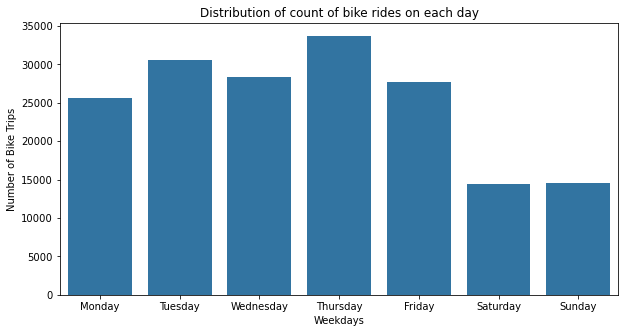

```python
def barplot(value, title, xlabel, ylabel, plt_order=None, base_color = sb.color_palette()[0]):
    base_color = sb.color_palette()[0]
    sb.countplot(x = value, color=base_color , data = rides, order=plt_order)
    plt.title(title)
    plt.xlabel(xlabel)
    plt.ylabel(ylabel)
    plt.show()

plt.figure(figsize = [10, 5])
day_order = ['Monday', 'Tuesday', 'Wednesday', 'Thursday', 'Friday', 'Saturday', 'Sunday']
barplot('weekday_of_start', 'Distribution of count of bike rides on each day', 'Weekdays', 'Number of Bike Trips', plt_order=day_order)
```

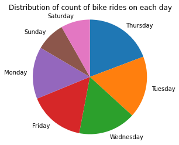

```python
# Create a piechart to show the levels of usage per weekday
weekday_counts = rides['weekday_of_start'].value_counts()

plt.pie(weekday_counts, labels = weekday_counts.index, startangle = 90, counterclock = False);
plt.title('Distribution of count of bike rides on each day');

plt.axis('square');
```

It can be observed that the service is used most on Thursdays and least on Saturdays

### What type of person uses the service the most?

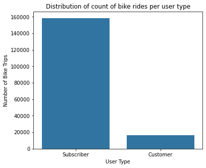

```python
# Create a barplot to show the levels of usage per user type
plt.figure(figsize = [6, 5])
plt_order = rides['user_type'].value_counts().index
barplot('user_type', 'Distribution of count of bike rides per user type', 'User Type', 'Number of Bike Trips', plt_order)
```

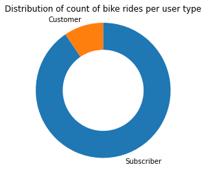

```python
# Create a donut plot to show the levels of usage per user type
user_type_counts = rides['user_type'].value_counts()

plt.pie(user_type_counts, labels = user_type_counts.index, startangle = 90,
        counterclock = False, wedgeprops = {'width' : 0.4});
plt.title('Distribution of count of bike rides per user type');
plt.axis('square');
```

It can be noted that subscribers use the service much more frequently than casual users

### What hour of the day do people mostly use the service?

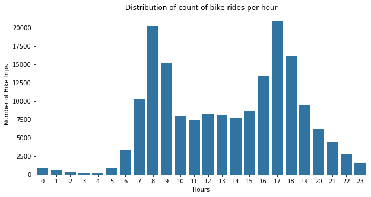

```python
# Create a seaborn countplot to display the different hours of the day and the usage of the service
plt.figure(figsize = [10, 5])
base_color = sb.color_palette()[0]
sb.countplot(data=rides, x='start_hour', color=base_color)
plt.xlabel('Hours')
plt.ylabel('Number of Bike Trips')
plt.title('Distribution of count of bike rides per hour');
```

It can be observed that the bike service is mostly used in the morning between the hours of 8 and 9am and in the afternoon between the hours of 5 and 6pm

### What age range use the bike service the most?

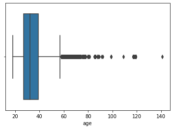

```python
# First create a boxplot to identify outliers
sb.boxplot(data=rides, x='age');
```

It can be observed that there are a few ages above 60. These can be treated as outliers.

```python
# Query data for people below age 60
rides = rides.query('age < 60')
```

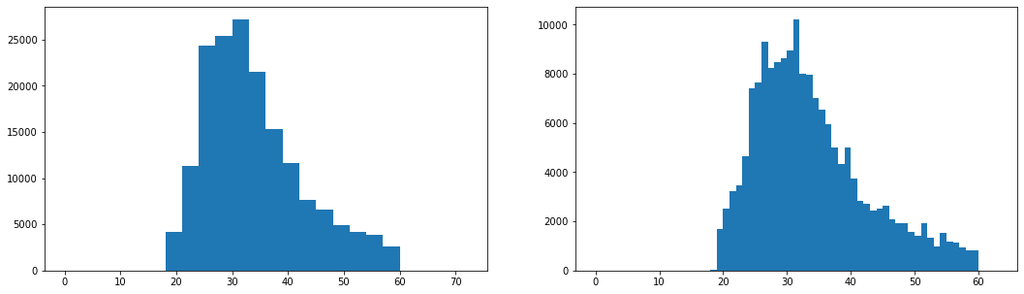

```python
# Create subplots using different bins to explore age distribution for the bike trips
plt.figure(figsize = [18, 5])

plt.subplot(1, 2, 1)
bins = np.arange(0, rides['age'].max()+15, 3)
plt.hist(data = rides, x = 'age', bins = bins);

plt.subplot(1, 2, 2)
bins = np.arange(0, rides['age'].max()+5, 1)
plt.hist(data = rides, x = 'age', bins = bins);
```

It can be noted that people between the ages of 29 to 33 years use the service the most

### What gender uses the service the most?

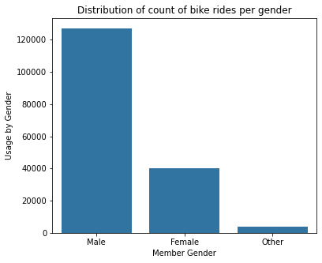

```python
plt.figure(figsize = [6, 5])
plt_order = rides['member_gender'].value_counts().index
barplot('member_gender', 'Distribution of count of bike rides per gender', 'Member Gender', 'Usage by Gender', plt_order)
```

It can be observed that males use the bike service much more than anyone else

### What is the average time taken in seconds for the trips

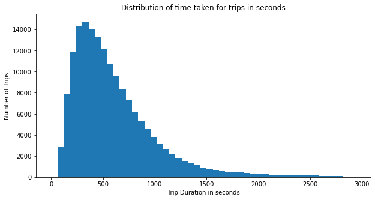

```python
plt.figure(figsize = [10, 5])
bins = np.arange(0, 3000, 60)
plt.hist(data = rides, x = 'duration_sec', bins = bins)
plt.title("Distribution of time taken for trips in seconds")
plt.xlabel('Trip Duration in seconds')
plt.ylabel('Number of Trips');
```

It can be observed that most people finish thier trips in about 300 to 400 seconds

### Discuss the distribution(s) of your variable(s) of interest. Were there any unusual points? Did you need to perform any transformations?

Different bins were required for the age distribution to observe which one gave the best visualization

### Of the features you investigated, were there any unusual distributions? Did you perform any operations on the data to tidy, adjust, or change the form of the data? If so, why did you do this?

The distribution for the duration of the trips in seconds was extremely skewed to the right showing that most people finished their rides earlier and that as time went on, less and less people continued the trip.

## Bivariate Exploration

### What is the relationship between age and trip duration?

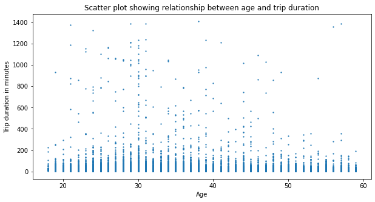

```python
# Create a scatter plot to explore relationship between age and trip duration
plt.figure(figsize = [10, 5])
sb.regplot(x = 'age', y = 'duration_min', color=base_color , data = rides, fit_reg = False, scatter_kws={'s':2});
plt.title('Scatter plot showing relationship between age and trip duration')
plt.xlabel('Age')
plt.ylabel('Trip duration in minutes')
plt.show()
```

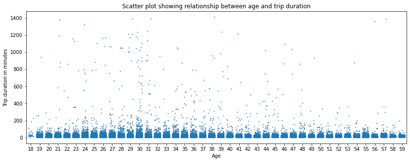

```python
plt.figure(figsize = [14, 5])
sb.stripplot(x = 'age', y = 'duration_min', color=base_color , data = rides, jitter = 0.35, size = 2);
plt.title('Scatter plot showing relationship between age and trip duration')
plt.xlabel('Age')
plt.ylabel('Trip duration in minutes')
plt.show()
```

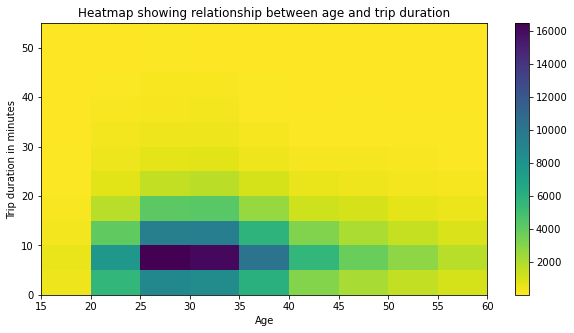

```python
plt.figure(figsize = [10, 5])

bins_x=np.arange((rides['age'].min()//5)*5, rides['age'].max()+5,5)
bins_y=np.arange((rides['duration_min'].min()//5)*5, rides['duration_min'].quantile (0.99)+5,5)

plt.hist2d(data = rides, x = 'age', y = 'duration_min', cmin=0.5, cmap='viridis_r', bins=[bins_x, bins_y])
plt.colorbar()
plt.xlabel('Age')
plt.ylabel('Trip duration in minutes')
plt.title('Heatmap showing relationship between age and trip duration');
```

### What gender has a higher trip duration?

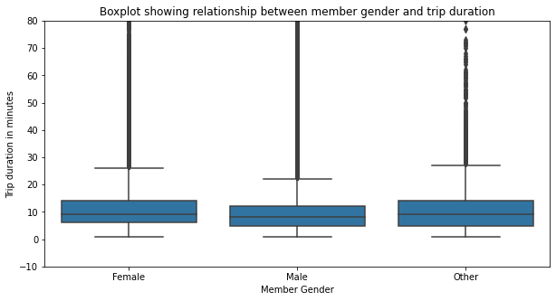

```python
# Define a function for a boxplot to be used subsequently
def boxplot(value1, value2, title, xlabel, ylabel, base_color = sb.color_palette()[0]):
    sb.boxplot(x = value1, y = value2, color=base_color , data = rides)
    plt.ylim(-10, 80)
    plt.title(title)
    plt.xlabel(xlabel)
    plt.ylabel(ylabel)
    plt.show()

plt.figure(figsize = [10, 5])
boxplot('member_gender', 'duration_min', 'Boxplot showing relationship between member gender and trip duration', 'Member Gender', 'Trip duration in minutes')
```

From the boxplot it can be observed that the females and other gender took longer trips as compared to the males

### What user type took longer trips?

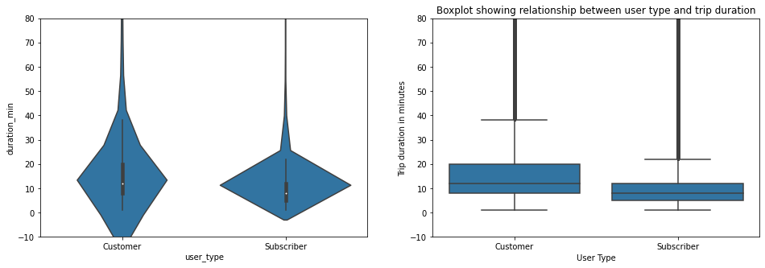

```python
# Create a boxplot and violinplot for user type and trip duration
plt.figure(figsize = [16, 5])
base_color = sb.color_palette()[0]

plt.subplot(1, 2, 1)
sb.violinplot(data=rides, x='user_type', y='duration_min', color=base_color)
plt.ylim(-10, 80)

plt.subplot(1, 2, 2)
boxplot('user_type', 'duration_min', 'Boxplot showing relationship between user type and trip duration', 'User Type', 'Trip duration in minutes')
```

From the boxplot it can be observed that the customers took longer trips as compared to the subscribers

### What was the age of people who used the service the most on each day?

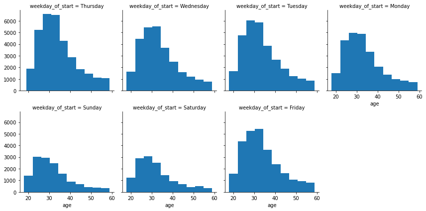

```python
# Create a facetgrid for weekdays and age
def grid(value1, value2):
    g = sb.FacetGrid(data = rides, col = value1, col_wrap=4)
    g.map(plt.hist, value2);

grid('weekday_of_start', 'age')
```

It can be observed that people between the age of 28 and 33 years used the service the most on each day of the week

### What gender was older on the average?

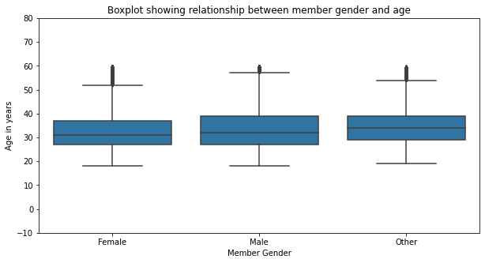

```python
# Create a boxplot for gender and age
plt.figure(figsize = [10, 5])
boxplot('member_gender', 'age', 'Boxplot showing relationship between member gender and age', 'Member Gender', 'Age in years')
```

From the boxplot it can be observed that the male and other gender were older than the females

### What user type was older on the average?

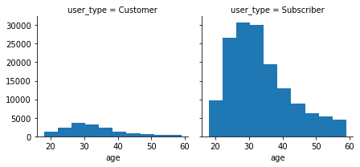

```python
# Create a facetgrid for user type and age
grid('user_type', 'age')
```

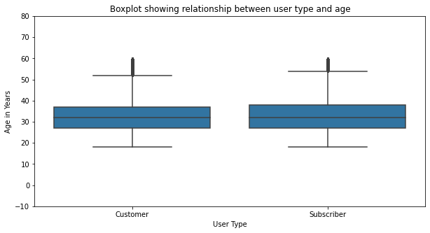

```python
# Create a boxplot for user type and age
plt.figure(figsize = [10, 5])
boxplot('user_type', 'age', 'Boxplot showing relationship between user type and age', 'User Type', 'Age in Years')
```

## Multivariate Exploration

> Create plots of three or more variables to investigate your data even further. Make sure that your investigations are justified, and follow from your work in the previous sections.

### What type of user used the service most on each weekday?

```python
# Use group_by() and size() to get the counts of each user type on weekdays
user_counts = rides.groupby(['weekday_of_start', 'user_type']).size()
```

```python
# Use the .reset_index() to convert a series into a dataframe object
user_counts = user_counts.reset_index(name='count')
```

```python
# Use the .pivot() to rearrange the data, to have weekdays on rows
user_counts = user_counts.pivot(index = 'weekday_of_start', columns = 'user_type', values = 'count')
```

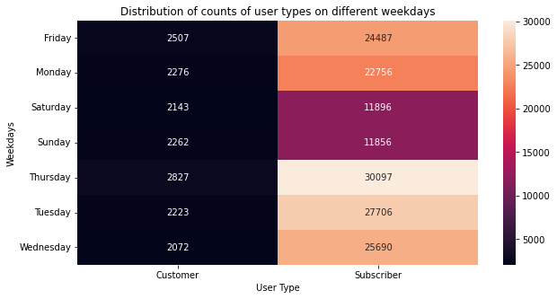

```python
# Create a heatmap for the distribution
plt.figure(figsize = [10, 5])
sb.heatmap(user_counts, annot = True, fmt = 'd')
plt.title('Distribution of counts of user types on different weekdays')
plt.xlabel('User Type')
plt.ylabel('Weekdays');
```

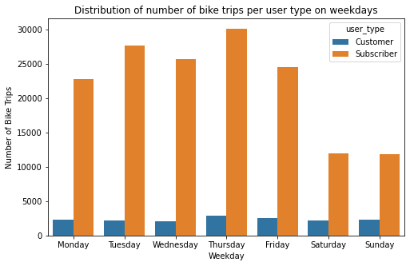

```python
# Define a function for a clustered bar chart
def barplot(value1, value2, plot_order, title, xlabel, ylabel):
    sb.countplot(data = rides, x = value1, hue = value2, order=plot_order)
    plt.title(title)
    plt.xlabel(xlabel)
    plt.ylabel(ylabel)
    plt.show()

plt.figure(figsize = [8, 5])
plot_order = day_order
barplot('weekday_of_start', 'user_type', plot_order, 'Distribution of number of bike trips per user type on weekdays', 'Weekday', 'Number of Bike Trips')
```

It can be oberved that subscribers took the most trips on each weekday with the most trips taken on Thurday

### On which day were the most trips taken and by which gender?

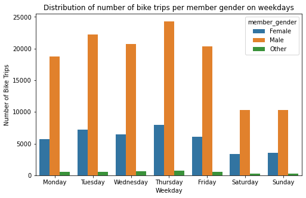

```python
plt.figure(figsize = [8, 5])
plot_order = day_order
barplot('weekday_of_start', 'member_gender', plot_order, 'Distribution of number of bike trips per member gender on weekdays', 'Weekday', 'Number of Bike Trips')
```

It can be observed that males took the most trips out of the genders. This can be attributed to the fact that the dataset has quite a large number of males.

### What gender of user type used the service the most?

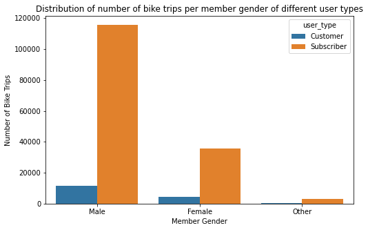

```python
plt.figure(figsize = [8, 5])
plot_order = rides['member_gender'].value_counts().index
barplot('member_gender', 'user_type', plot_order, 'Distribution of number of bike trips per member gender of different user types', 'Member Gender', 'Number of Bike Trips')
```

It can be observed that male subscribers used the service the most. This can be attributed to the fact that males are the most abundant gender in the dataset

### What time was the service used most and by who?

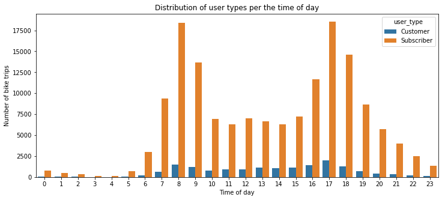

```python
plt.figure(figsize = [12, 5])
sb.countplot(data = rides, x = 'start_hour', hue = 'user_type', order=None)
plt.title('Distribution of user types per the time of day')
plt.xlabel('Time of day')
plt.ylabel('Number of bike trips')
plt.show()
```

It can be observed that subscribers used the service most and between the hours of 8-9am and 5-6pm.

### What time was the service used most and by who?

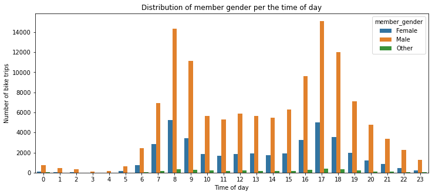

```python
plt.figure(figsize = [12, 5])
sb.countplot(data = rides, x = 'start_hour', hue = 'member_gender', order=None)
plt.title('Distribution of member gender per the time of day')
plt.xlabel('Time of day')
plt.ylabel('Number of bike trips')
plt.show()
```

It can be oberved that males used to service most no matter the time of day

### What gender takes a longer trip?

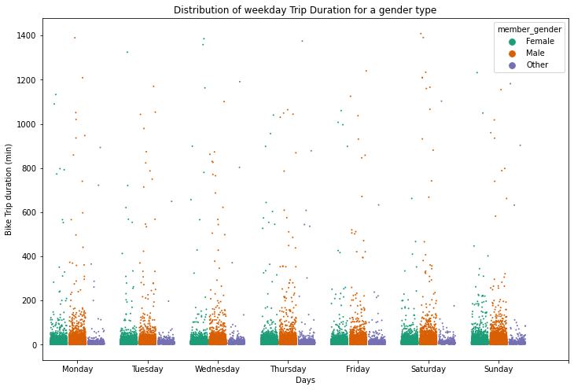

```python
# Create a stripplot to explore which gender took a longer trip
plt.figure(figsize=[12, 8])

sb.stripplot(data = rides, x = 'weekday_of_start', y = 'duration_min', hue = 'member_gender', palette = 'Dark2', order = day_order,
            jitter = 0.35, dodge = 2, size = 2)
plt.title('Distribution of weekday Trip Duration for a gender type')
plt.ylabel('Bike Trip duration (min)')
plt.xlabel('Days')
plt.xticks(np.arange(0, 7 + 1, 1))
plt.show()
```

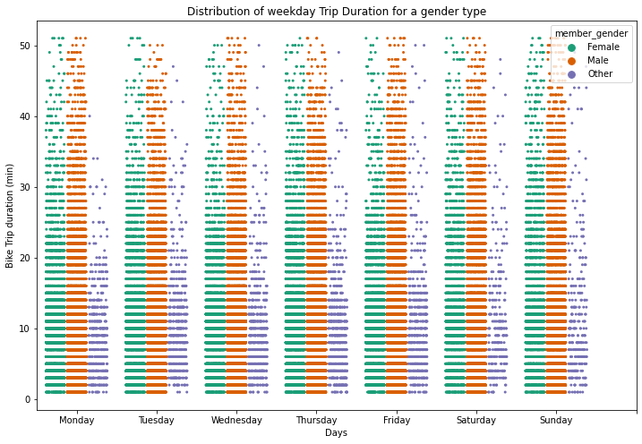

```python
# Remove outliers from stripplot
plt.figure(figsize=[12, 8])

sb.stripplot(data = rides.query('duration_min < duration_min.quantile(0.99)'), x = 'weekday_of_start', y = 'duration_min', hue = 'member_gender', palette = 'Dark2', order = day_order,
            jitter = 0.35, dodge = 2, size = 3)
plt.title('Distribution of weekday Trip Duration for a gender type')
plt.ylabel('Bike Trip duration (min)')
plt.xlabel('Days')
plt.xticks(np.arange(0, 7 + 1, 1))
plt.show()
```

### Talk about some of the relationships you observed in this part of the investigation. Were there features that strengthened each other in terms of looking at your feature(s) of interest?

The dataset had a lot of males so most of the features had the most male counts

### Were there any interesting or surprising interactions between features?

Yes, this is because even though the dataset had more males than the rest, it was observed that females and others however took longer trips than males. This could be because females on the average were younger than the males.